# Power Spectra & Spectral Factorization

Table of Contents

Introduction A Stationary Stochastic Process from a White Noise Response of an LTI Filter - A First Example Solution Q&A A Spectral Shaping Filter Evaluating the Process Variance The Complex Spectrum Symmetric Polynomials Remark Applying the Spectral Factorization Algorithm The Spectral Factorization Theorem An Usefull Trick The Spectral Factorization Algorithm: a Summary The Resulting Factorization The Spectral Shaping Filter

## Introduction

In this live script, we offer a few examples of solving, using MATLAB code, simple problems involving computation of the power spectra of stationary stochastic processes, the spectral factorization and the so-called canonical spectral factorization.

What you will learn:

- How to cope with a spectral factorization problem using MATLAB;
- How to manage a spectrum of a stochastic proces with the aim to obtain a canonical spectral factorization;
- How to evaluate the autocorrelation function of a stationary stochastic process, given its complex spectrum, and viceversa.

For a while we'll use the Symbolic Toolbox

```matlab
clear variables
close all
clc

sympref('HeavisideAtOrigin', 1); % setting the Symbolic Toolbox
```

## A Stationary Stochastic Process from a White Noise Response of an LTI Filter - A First Example

Consider a stationary stochastic process $y(t)$, generated by an LTI dynamic system with transfer function

$W(z) = \displaystyle \frac{1}{z-0.5}$

and white noise $\eta(t)$ as its input. Assume that $\eta(t)$ has a zero-mean and a unitary variance: $\eta(\cdot) \sim \text{WN}(0,\,1)$

Find the power spectrum $\Gamma_y(\omega)$ and the autocorrelation function $\gamma_y(\tau)$ of $y(t)$.

### Solution

Since $y(t)$ is the output of the LTI system $W(z)$ (the filter) and the input is the unit-variance and zero-mean white noise $\eta(t)$, then the spectrum $\Phi(z)$ can be expressed as

$\Phi_{y}(z) = W(z) \cdot W\left(\displaystyle \frac{1}{z} \right) \cdot \Phi_{\eta}(z) = W(z) \cdot W\left(\displaystyle \frac{1}{z} \right) \cdot 1 = W(z) \cdot W\left(\displaystyle \frac{1}{z} \right)$

```matlab
syms z n

Wz = 1/(z-0.5)  % the LTI system
```

Wz =

```matlab
sigma2_eta = 1; % the variance of the white noise
```

Thus the process spectrum is

```matlab
W_z1 = subs(Wz, z, (z^(-1)))
```

W_z1 =

```matlab
PhiZ = Wz*W_z1*sigma2_eta
```

PhiZ =

Evaluating for $z=e^{i\,\omega$ we obtain $\Gamma_y(\omega)$

```matlab
syms omega
Gamma_y = subs(PhiZ, z, exp(1i*omega))
```

Gamma_y =

Rewrite $\Gamma_y(\omega)$ exploiting the Euler's formula

$e^{i\,\omega} = \cos \omega +i\,\sin \omega$

where i is the imaginary unit. Thus

$\cos \omega = \displaystyle \frac{e^{i\,\omega}+e^{-i\,\omega}}{2}\quad$

```matlab
Gamma_y = simplify(rewrite(Gamma_y, "cos"))
```

Gamma_y =

The spectrum is

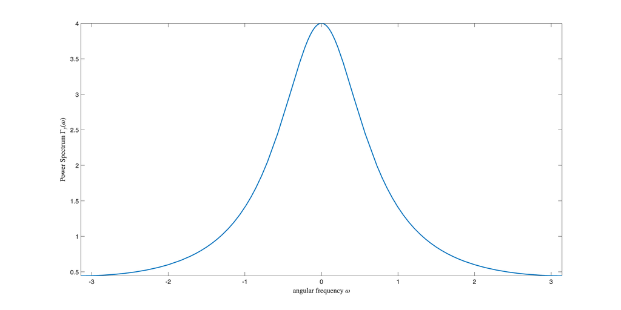

```matlab
figure('Units','normalized','Position',[0.1,0.1,0.9,0.8]);
fplot(gca, Gamma_y, [-pi, pi], 'LineStyle','-','LineWidth',1.5);
% plot the curve defined by the function y = Gamma_y(omega) over the
% interval [-pi , +pi]
xlabel('angular frequency $\omega$', 'Interpreter','latex');
ylabel('Power Spectrum $\Gamma_{y}(\omega)$', 'Interpreter','latex')
```

### Q&A

- Q1: Given the expression of $W(z)$, to which family of rational spectrum processes does the analyzed stochastic process belong?
- Q2a: Is the spectral factorisation canonical or not? Q2b: Why? Q2c: If not, what can the canonical spectral factorisation be?
- A2c: the canonical spectral form is $\hat{W}(z)=\displaystyle \frac{z}{z-0.5} \quad \xi(\cdot) \sim \text{WN}(0, 1)$
- Q3: What is the variance of the process?
- A3: $\sigma_{y}^2 = \displaystyle \frac{1}{2\, \pi} \int_{-\pi}^{+\pi} \, \Gamma_y(\omega) \,d\omega$ or, exploiting the spectral canonical form $\sigma_{y}^2 = \displaystyle \frac{\lambda^2_{\xi}}{(1-a^2)} = \displaystyle \frac{1}{1-0.25} = \displaystyle \frac{4}{3}$

```matlab
sigma2_y =  double((1/(2*pi))*int(Gamma_y,omega, [-pi,pi] ))
```

sigma2_y = 1.3333

```matlab
sym(sigma2_y)
```

ans =

- Q4: Given the spectral canonical factorization, what is the autocorrelation function?
- A4: For an AR(1) stationary process the autocorrelation function is $\gamma_{y}(\tau) = \displaystyle \frac{\lambda^2_{\xi}}{(1-a^2)} a^{\vert \tau \vert}= \displaystyle \frac{4}{3} \left(\displaystyle \frac{1}{2} \right)^{\vert \tau \vert}$

## A Spectral Shaping Filter

Suppose we want to generate a stationary stochastic process characterised by the following power spectrum

$\Gamma_{y}(\omega) = \displaystyle \frac{5+4\, \cos\omega}{13+12\,\cos \omega} \qquad \omega \in \left[ -\pi\,,\; +\pi \right]$

by filtering unit-variance and zero-mean white noise $\eta(t)$ with an asymptotically stable LTI system

Find the transfer function $W(z)$ of the filter.

```matlab
clear variables
```

Let us define the angular frequency ω as symbolic variable, and then assign the spectrum

```matlab
syms omega
Gamma_y = (5+4*cos(omega))/(13+12*cos(omega))
```

Gamma_y =

#### Evaluating the Process Variance

Given the expression of the power spectrum $\Gamma_y(\omega)$, the variance of the r.v. $y(t)$ can be determined evaluating the integral

$\sigma_{y}^2 = \displaystyle \frac{1}{2\, \pi} \int_{-\pi}^{+\pi} \, \Gamma_y(\omega) \,d\omega$

```matlab
sigma2_y =  ( (1/(2*pi))*int(Gamma_y,omega, [-pi,pi] ))
```

sigma2_y =

Not so clearly readable. A better way to obtain a readable result is

```matlab
sigma2_y_ALT =  double(sigma2_y)
```

sigma2_y_ALT = 0.4667

```matlab
Sigma2Y = sym(sigma2_y_ALT)
```

Sigma2Y =

Now the result is clearly readable.

#### The Complex Spectrum $\Phi(z)$

Rewrite $\Gamma_y(\omega)$ exploiting the Euler's formula

$e^{i\,\omega} = \cos \omega +i\,\sin \omega$

where i is the imaginary unit. Thus

$\cos \omega = \displaystyle \frac{e^{i\,\omega}+e^{-i\,\omega}}{2}\$

and we obtain

```matlab
Gamma_y = rewrite(Gamma_y, "exp")
```

Gamma_y =

#### Symmetric Polynomials

Now, replacing $e^{i\,\omega}$ with the complex variable z we obtain the expression of the desired complex spectrum $\Phi(z)$, as the bilateral Z-transform of the autocorrelation function $\gamma_y(\tau)$

```matlab
syms z

PhiZ = subs(Gamma_y, exp(1i*omega), z)
```

PhiZ =

Note the peculiar structure of the polynomials at the numerator and the denominator in the expression of the spectrum. They are symmetric polynomials in the variables z and $z^{-1}$ . In fact, permuting the variable z with $z^{-1}$ does not change the expression of both the polynomials.

### Remark

The feature just highlighted is in fact a peculiar property of rational spectra: one can always write the two polynomials that appear in the spectrum as symmetrical polynomials in z and $z^{-1}$. More details are available in the live function applying the canonical spectral factorization algorithm.

### Applying the Spectral Factorization Algorithm

Note that in this live script we are applying the "Spectral Factorization Algorithm", summarising the steps of the algorithm itself, but without any sketch of proof or any explanation. For details on the algorithm and some explanation, please refer to the live function implementing the spectral factorization algorithm.

#### The Spectral Factorization Theorem

Given a process with rational spectrum $\Phi(z)\,$, there exists one and only one representation of the process as the output of an LTI system driven by a white process $\xi(\cdot)$ and with transfer function $W(z) = \frac{N(z)}{D(z)}$ if the following conditions are imposed on $W(z)\,$:

- $N(z)\,$ and $D(z)\,$ monic, co-prime and of the same degree;
- all roots of $N(z)\,$ (zeros of $W(z)\,$ ) have $\vert \,\cdot\,\vert \le 1\,$;
- all roots of $D(z)\,$ (poles of $W(z)\,$ ) have $\vert \,\cdot\,\vert < 1\,$.

$\Phi_{y}(z) = W(z) \cdot W\left(\displaystyle \frac{1}{z} \right) \cdot \Phi_{\xi}(z) = W(z) \cdot W\left(\displaystyle \frac{1}{z} \right) \cdot \lambda^2_{\xi}$

#### An Usefull Trick

In order to apply the "Spectral Factorization Algorithm" we have to determine the coefficients of both the symmetric polynomials at the numerator and the denominator in the rational spectrum expression.

A simple trick to obtain the needed polynomial coefficients is based on the symbolic variable substitution $\left(z+z^{-1}\right) \longrightarrow x$ into the expression of $\Phi(z)$

```matlab
syms x
PhiX = subs(PhiZ,(z+z^(-1)), x) % the first step of the trick: substituting the expression
```

PhiX =

```matlab
% the second step of the trick: get numerator and denominator of the
% symbolic expression PhiX
[betaX, alphaX] = numden(PhiX)
```

betaX =

alphaX =

Finally, extract the coefficient array from each polynomial, ordered from the highest to the lowest degree of the monomials in the instrumental variable x

```matlab
betaPoly = sym2poly(betaX) % the coefficients of the numerator of the spectrum, as a symmetric polynomial
```

betaPoly = 1×2

2 5

```matlab
% betaPoly contains the floating-point description of the coefficients,
% from the highest to the lowest degree monomial of the auxiliary variable x
```

```matlab
alphaPoly = sym2poly(alphaX) % the coefficients of the denominator of the spectrum, as a symmetric polynomial
```

alphaPoly = 1×2

6 13

```matlab
% alphaPoly contains the floating-point description of the coefficients,
% from the highest to the lowest degree monomial of the auxiliary variable x
```

Now we re ready to apply the Spectral Factorization Algorithm.

#### The Spectral Factorization Algorithm: a Summary

Given the rational spectrum

$\Phi(z) = \displaystyle \frac{\beta(z)}{\alpha(z)} = \displaystyle \frac{\displaystyle \sum_{k=-m}^{m}\, \beta_k\,z^k}{\displaystyle \sum_{k=-n}^{n}\,\alpha_k\,z^k}$

with

$\left\{ \begin{array}{lcl} \alpha_p = \alpha_{-p} &\quad& p=-n\,,\,-n+1\,,\, \cdots ,\, n-1\,,\, n \\ \beta_q = \beta_{-q} &\quad& q=-m\,,\,-m+1\,,\, \cdots ,\, m-1\,,\, m \\ \alpha_n \ne 0 \,,\; \beta_m \ne 0 &\quad& \text{i.e. both polynomials are symmetric polynomials in $z$ and $z^{-1}$} \\ \Phi\left(e^{i\,\omega} \right) \ge 0 \; \forall \omega& \quad &\text{i.e. $\Phi(z)$ is a rational spectrum} \end{array} \right.$

then there is only one factorization of the spectrum $\Phi(z)$ such that

$\Phi(z) = \displaystyle \frac{C(z)}{A(z)} \cdot \frac{C\left(z^{-1}\right)}{A \left(z^{-1}\right)} \cdot r$

with

$\left\{ \begin{array}{rcl} r &>& 0 \\ A(z) &=& 1+a_1\,z^{-1}+a_2\,z^{-2}+\cdots+a_n\,z^{-n} \quad \text{with } z_p: A(z_p) = 0 \,,\; \vert z_p \vert <1 \; \forall p \\ C(z) &=& 1+c_1\,z^{-1}+c_2\,z^{-2}+\cdots+c_m\,z^{-m} \quad \text{with } z_q: C(z_q) = 0 \,,\; \vert z_q \vert \le 1 \; \forall q \end{array} \right.$

First step of the algorithm: exploiting the fact that both $\alpha(z)$ and $\beta(z)$ are symmetric polynomials, factor both the polynomials

$\left\{ \begin{array}{rcl} \alpha(z) &=& r_1\, A(z)\, A\left(z^{-1}\right) \\ \beta(z) & =& r_2\, C(z)\, C\left(z^{-1}\right) \end{array} \right.$

where $r_1>0$, $r_2>0$ and the polynomials $A(z)$ and $C(z)$ are monic polynomials as defined above.

Second step of the algorithm: the spectral factorization of $\Phi(z)$ is

$\Phi(z) = \displaystyle \frac{\beta(z)}{\alpha(z)} = \left( \frac{r_2}{r_1} \right)\cdot \left[ \frac{C(z)}{A(z)} \right] \cdot \left[\frac{C\left(z^{-1}\right)}{A\left(z^{-1}\right)} \right] = r \cdot W(z) \cdot W\left(z^{-1}\right)$

#### The Resulting Factorization

Given the description of both the polynomials $\beta(z)$ and $\alpha(z)$ as symmetric polynomials, we can obtain the spectral factorization simply using the live function L8_spectrFactAlg()

```matlab
[r, Cz_coeffs, Az_coeffs] = L8_spectrFactAlg(betaPoly, alphaPoly)
```

r = 0.4444

Cz_coeffs = 1×2

1.0000 0.5000

Az_coeffs = 1×2

1.0000 0.6667

Now rewrite the result as symbolic rational function

```matlab
% sort the display output of polynomial function in ascending order, i.e.
% according to the order of each monomial teerm
sympref('PolynomialDisplayStyle','ascend');

syms z1 % a trick to represent in a compact way 1/z

lambda2xi = sym(r) % the white noise spectrum
```

lambda2xi =

```matlab
Az1 = poly2sym(fliplr(Az_coeffs), z1) % the polynomial A(z)
```

Az1 =

```matlab
Az = subs(Az1,z1,z^(-1))
```

Az =

```matlab
Cz1 = poly2sym(fliplr(Cz_coeffs), z1) % the polynomial C(z)
```

Cz1 =

```matlab
Cz = subs(Cz1,z1,z^(-1))
```

Cz =

```matlab
Wz = Cz1/Az1 % the LTI system transfer function as symbolic object
```

Wz =

#### The Spectral Shaping Filter

Finally, the transfer function of the LTI filter $W(z)$ is

```matlab
W_z = tf(Cz_coeffs, Az_coeffs, 1, 'Variable','z^-1')
```

W_z = 1 + 0.5 z^-1 --------------- 1 + 0.6667 z^-1 Sample time: 1 seconds Discrete-time transfer function.

In conclusion, the power spectrum

$\Gamma_{y}(\omega) = \displaystyle \frac{5+4\, \cos\omega}{13+12\,\cos \omega} \qquad \omega \in \left[ -\pi\,,\; +\pi \right]$

is associated to the following model

- a stationary white noise process $\eta(\cdot) \sim \text{WN}\left(0\,,\; \displaystyle \frac{4}{9} \right)$
- an LTI stable system, with transfer function $W(z) = \displaystyle \frac{1+\frac{1}{2}\,z^{-1}}{1+\frac{2}{3}\,z^{-1}}$

Thus we found the spectral canonical form of an ARMA(1, 1) stationary stochastic process.